# Fletcher and Fortin, Chapter 6

Varied Thrush Example Walkthrough

# 1 Introduction and Overview

This is a walkthroug of a spatial analysis workflow, based of section **6.3.3: Models that Ignore Spatial Dependence** in

> Fletcher, Robert; Fortin, Marie-Josée. Spatial Ecology and Conservation Modeling

- This walkthrough uses the **Simple Features** ecosystem of R spatial tools in this walkthrough.
- This walkthrough uses the `ggplot` plotting methods, for the most part.
- This walkthrough uses pipe operator `%>%` when appropriate:
  - I like to keep the envirnoment free of intermediate variables.
  - Pipes aren’t always the best option, but they can make compace and elegant code.
  - Here is some info on from the [University of Chicago](https://cfss.uchicago.edu/notes/pipes/)

## 1.1 The data

Surveys for the varied thrush: *Ixoreus naevius*

- Sampling scheme:
- ~3km transects
- point surveys - 100m radius
- 10 pts/transect

## 1.2 Errata

There are a number of errata in the code provided by the authors, both in the main text and the supplemental code. I’ll attempt to point out where I found issues and offer my corrections.

### 1.2.1 general

- The authors’ elevation raster files don’t include projection information.
- The code in the text doesn’t include projection info.
- The projection specification is found in the supplemental code.

### 1.2.2 correlogram function

There is a mistake in the definition of the `moran.results` data frame:

They define two columns called `null.lower`, however one of them should have been `null.upper`

# 2 Data

## 2.1 Packges, environment

Packages used in this walkthrough.

Note: I use `here()` in conjunction with the file path to the F&F data on my computer. You’ll need to tell R where to look for the data on your machine.

```r
{
  require(here)
  require(data.table)

  # simple features packages
  require(stars)
  require(sf)

  # original spatial packages
  require(raster)
  require(sp)

  # ggplot related packages
  require(ggplot2)
  require(cowplot)
  require(viridis)

  # for a nice pair plot function
  require(psych)

  # for Moran's I function
  require(spdep)

  # CRS for the raster and point data
  crs_dat = "+proj=aea +lat_1=46 +lat_2=48 +lat_0=44 +lon_0=-109.5 +x_0=600000 +y_0=0 +ellps=GRS80 +datum=NAD83 +units=m +no_defs"

  # Save output images?
  save_images = FALSE
  save_images = TRUE
  execute = TRUE
}
```

## 2.2 Elevation data

I’m initially reading the raster with `raster()` rather than the stars. I’m sure there’s a stars-friendly pre-built terrain function, but I haven’t found it yet.

Finally, group everythign into a multilayer raster `stars` object.

```r
{
  dem = raster(file.path(book_data, "elev"))
  proj4string(dem) = crs_dat

  # There are a bunch of zeroes in the data, but there are no regions in the intermountain
  # west with elevaiton of 0.
  # Replace these with NA
  dem[][dem[] == 0] = NA

  dem_m = dem
  dem_m[] = dem[] * 1e3

  dat_brick = brick(dem_m, terrain(dem_m, opt = c("slope", "aspect"), unit = "radians"))

  names(dat_brick)[1] = "elevation"
  terrain_brick = st_as_stars(dat_brick)

  # resamplign to make plotting faster
  r_t = raster(extent(dat_brick), resolution = 5000)
  terrain_brick_rs = st_as_stars(resample(dat_brick, raster(extent(dat_brick), resolution = 5000)))
  # terrain_brick_rs = st_as_stars(resample(dat_brick, raster(extent(dat_brick), resolution = 5000)))

  rm(dem_m, dem)
}
```

## 2.3 Varied Thrush Data

- I prefer opening tabular data files with `data.table`, it ‘just works’ much more often than `read.csv()`.
- You can make a `sf` object from a `data.frame` or `data.table` with `st_as_sf()`
- I have been unsuccessful at finding a quick way to extract values from a stars raster brick given point coordinates.
  - This code uses `extract()` on the `RasterBrick` version of the data to add terrain info to the thrush data.

```r
{
  thrush_dt =
    fread(file.path(book_data, "vath_2004.csv"), header = TRUE)

  thrush_dt[, present := ifelse(VATH == 0, "absent", "present")]
  thrush_dt[, count := VATH]

  thrush_sf = st_as_sf(
    thrush_dt,
    coords = c("EASTING", "NORTHING"),
    crs = crs_dat)

  thrush_sf = cbind(thrush_sf, extract(dat_brick, thrush_dt[, .(x = EASTING, y = NORTHING)]))
}
```

## 2.4 Center data

The authors centered and scaled, i.e. a z-transfomation, for the modeling. The resulting centered/scaled variables have mean 0 and variance 1.

```r
{
  thrush_sf$elevation_sc = scale(thrush_sf$elevation, center = T, scale = T)
  thrush_sf$slope_sc = scale(thrush_sf$slope, center = T, scale = T)
  thrush_sf$aspect_sc = scale(thrush_sf$aspect, center = T, scale = T)
}
```

# 3 Graphical paramaters

For simpler plotting coding later, I’ve created ggplot objects here.

## 3.1 Plot params

Crate ggplot objects for building the plots later.

```r
{
  # Thrush data histogram params
  hist_col = "black"
  hist_fill = "steelblue"
  hist_fill_2 = rgb(0, 0.6, 0.9)
  hist_alpha = 0.2

  elev_tmp = c(terrain_brick[, , , 1]$elevation)
  rng = range(elev_tmp[elev_tmp > 0], na.rm = T)

  gm_hist_1 =
    geom_histogram(binwidth = 1, color = hist_col, fill = hist_fill, alpha = hist_alpha)
  gm_thrush_hist_1 =
    geom_histogram(bins = 30, color = hist_col, fill = hist_fill, alpha = hist_alpha)
  gm_thrush_hist_2 =
    geom_histogram(bins = 30, color = hist_col, fill = hist_fill_2, alpha = hist_alpha)
  gm_thrush_hist_3 =
    geom_histogram(bins = 18, color = hist_col, fill = hist_fill_2, alpha = hist_alpha)

  # Map color and legend params
  legend_width = 0.4

  map_cb =
    guide_colorbar(
      title.position = "left",
      barwidth = unit(legend_width, "npc"))

  gg_thrush_start = 0.1

  gg_thrush_elevation =
    scale_fill_gradientn(
      colours = gray.colors(3, start = gg_thrush_start),
      na.value = "transparent",
      guide = map_cb,
      limits = c(rng[1], rng[2])
    )

  gg_map_vir =
    scale_fill_viridis(
      na.value = "transparent",
      guide = map_cb)

  gg_map_grayscale =
    scale_fill_gradientn(
      colours = gray.colors(3),
      na.value = "transparent",
      guide = map_cb)

  gg_map_terr =
    scale_fill_gradientn(
      colours = terrain.colors(20),
      na.value = "transparent",
      guide = map_cb)

  gg_map_heat =
    scale_fill_gradientn(
      colours = heat.colors(3),
      na.value = "transparent",
      guide = map_cb)

  gg_map = ggplot() +
    coord_equal() +
    scale_x_discrete(expand=c(0,0)) +
    scale_y_discrete(expand=c(0,0)) +
    theme_map() +
    theme(
      legend.position = "bottom",
      legend.direction = "horizontal",
      axis.title = element_blank())

  rm(rng, elev_tmp)
}
```

## 3.2 Pair plot

```r
{
  pairs.panels(
    data.frame(thrush_sf)[,
                          c("elevation", "slope", "aspect")])
}
```

## 3.3 Census histograms

```r
{
  require(grid)
  require(ggplotify)
  require(ggplot2)

  pplot = as.ggplot(
    ~pairs.panels(
      data.frame(thrush_sf)[, c("elevation", "slope", "aspect")]))

  g_hist_census =
    ggplot(
      aggregate(
        VATH ~ TRANSECT,
        data = thrush_sf, sum),
      aes(x = VATH)) +
    gm_hist_1 +
    labs(
      title = "Varied Thrush Census",
      subtitle = "Counts aggregated by transect") +
    xlab("Census Count")

  g_hist_census_points =
    ggplot(
      aggregate(
        VATH ~ TRANSECT * POINT,
        data = thrush_sf, sum),
      aes(x = VATH)) +
    gm_hist_1 +
    labs(
      title = "Varied Thrush Census",
      subtitle = "Counts aggregated by sample points in transects") +
    xlab("Census Count")
}
```

## 3.4 Terrain histograms

```r
{
  gm_hist_thrush = ggplot(thrush_sf) + gm_thrush_hist_2

  g_hist_elev =
    gm_hist_thrush + aes(x = elevation) +
    ggtitle("Sample Point Terrain: Elevation") +
    xlab("Elevation (m)")

  g_hist_slope =
    gm_hist_thrush +  aes(x = slope) +
    ggtitle("Sample Point Terrain: Slope") +
    xlab("Slope (m / km)")

  g_hist_aspect =
    gm_hist_thrush + aes(x = aspect) +
    ggtitle("Sample Point Terrain: Aspect") +
    xlab("Aspect (radians)")

  g_hist_terrain = plot_grid(
    g_hist_elev,
    g_hist_slope,
    g_hist_aspect, ncol = 1)

  # Conditional histograms
  gm_hist_thrush_present =
    ggplot(subset(thrush_sf, VATH == 1)) +
    gm_thrush_hist_3
  gm_hist_thrush_absent =
    ggplot(subset(thrush_sf, VATH == 0)) +
    gm_thrush_hist_3

  g_hist_elev_present =
    gm_hist_thrush_present + aes(x = elevation) +
    labs(
      title ="Sample Point Elevation",
      subtitle = "Thrushes Present") +
    xlab("Elevation (m)")

  g_hist_elev_absent =
    gm_hist_thrush_absent + aes(x = elevation) +
    labs(
      title = "Sample Point Elevation",
      subtitle = "Thrushes Absent") +
    xlab("Elevation (m)")

  g_hist_elev_cond = plot_grid(
    g_hist_elev_present, g_hist_elev_absent, nrow = 1)


}
```

## 3.5 Terrain maps

```r
{
  # original raster set for hi-resolution maps
  dat_br = terrain_brick

  # reduced-resolution raster set to speed up plotting
  dat_br = terrain_brick_rs

  # Select which color ramps to use for the maps
  cols = gg_map_grayscale
  cols = gg_map_terr

  map_elev =
    gg_map +
    geom_stars(data = dat_br[, , , 1]) +
    labs(fill = "Elevation") + cols

  map_slope =
    gg_map +
    geom_stars(data = dat_br[, , , 2]) +
    labs(fill = "Slope") + cols

  map_aspect =
    gg_map +
    geom_stars(data = dat_br[, , , 3]) +
    labs(fill = "Aspect") + cols

  map_terrain =
    plot_grid(
      map_elev,
      map_slope,
      map_aspect,
      nrow = 1)
}
```

## 3.6 Census maps

```r
{
  bb_inset = st_bbox(
    c(xmin = 170000,
      xmax = 210000,
      ymin = 500000,
      ymax = 551000),
    crs = crs_dat)

  # full resolution
  dat_br = terrain_brick

  # To speed  up test plots
  dat_br = terrain_brick_rs

  st_crs(terrain_brick_rs) = crs_dat

  thrush_inset = st_crop(thrush_sf, bb_inset)
  elev_inset = st_crop(terrain_brick[, , , 1], bb_inset)

  thrush_inset = st_crop(thrush_sf, bb_inset)
  elev_inset = st_crop(terrain_brick[, , , 1], bb_inset)

  cols = gg_thrush_elevation
  sc_census = scale_color_manual(name = "Varied Thrush", values = c(2, 3))

  thrush_inset_poly =
    geom_sf(data = st_as_sfc(bb_inset),
            fill = "transparent",
            col = rgb(0, 0.3, 0.001), size = 1.9)

  thrush_map =
    gg_map +
    geom_stars(data = dat_br[, , , 1]) +
    geom_sf(
      aes(colour = present),
      data = thrush_sf,
      size = 3, show.legend = FALSE) +
    labs(
      title = "Sampling Locations",
      subtitle = "Transects",
      fill = "Elevation") + cols + sc_census

  thrush_inset_map =
    gg_map +
    geom_stars(data = elev_inset, show.legend = FALSE) +
    geom_sf(
      aes(colour = present),
      data = thrush_inset,
      size = 2,
      show.legend = "point") +
    labs(
      title = "Sampling Locations",
      subtitle = "Census Sites",
      fill = "Elevation") +
    cols + sc_census +
    guides(
      colour = guide_legend(title.position="top", title.hjust = 0.5))
  # theme(legend.title = element_blank())

  thrush_map_full = plot_grid(
    thrush_map + thrush_inset_poly,
    thrush_inset_map, nrow = 1)

}
```

# 4 Custom Functions

Functions for creating and plotting correlograms

## 4.1 Correlogram functions

This is my version of the authors’ function for calculating a correlogram.

Note that there is a mistake in the definition of the `moran.results` data frame.

They define two columns called `null.lower`, however one of them should have been `null.upper`

```r
{
  ff_correlogram = function(point_coords, point_data, max_dist = NULL, bin_size = NULL, alpha = 0.05)
  {
    # package 'spdep' needed for dnearneigh() function.
    # Check whether it is installed:
    stopifnot(require(spdep))
    stopifnot(require(raster))

    if (is.null(max_dist))
    {
      # Euclidean distance betwen opposite corners of bounding box
      ext_coords = unlist(raster::extent(SpatialPoints(point_coords)))[1:4]
      max_dist = sqrt(diff(ext_coords[1:2])^2 + diff(ext_coords[3:4])^2) / 3
    }

    if (is.null(bin_size)) bin_size = max_dist / 20

    # Set up the distance bins
    dist_bins = seq(0, max_dist, by = bin_size)
    n_bins = length(dist_bins) - 1

    # container for results
    moran_out = data.frame(
      dist_class = rep(NA, n_bins),
      model_I = NA, model_p = NA,
      null_I_lower = NA, null_I_upper = NA)

    for (i in 1:n_bins)
    {
      d_lower = dist_bins[i]; d_upper = dist_bins[i+1]
      dist_class = mean(d_lower, d_upper)
      neigh =
        spdep::dnearneigh(x = point_coords, d1 = d_lower, d2 = d_upper, longlat = F)
      wts = nb2listw(neighbours = neigh, style = 'B',  zero.policy = TRUE)

      #note alternative is for P-value, so only 'significant if positive autocorrelation
      mor.i =
        moran.mc(
          x = point_data, listw = wts, nsim = 200,
          alternative = "greater", zero.policy = T)

      # null envelope
      null_env = quantile(mor.i$res, probs = c(alpha / 2, 1 - alpha / 2), na.rm = T)
      moran_out[i, ] = c(dist_class, mor.i$statistic, mor.i$p.value, null_env)
    }
    return(moran_out)
  }

  # Test case
  if (FALSE)
  {
    point_coords = st_coordinates(thrush_sf)
    point_data = thrush_sf$elevation
    bin_size = 300
    max_dist = 10000
    corr_1 = ff_correlogram(point_coords, point_data)
    head(corr_1)
    with(corr_1, matplot(x = dist_class, y = cbind(model_I, null_I_lower, null_I_upper), type = "l"))
  }
}
```

## 4.2 Plot correlogram

There’s also a convenience function for plotting the resulting correlogram.

```r
{
  plot_ff_correlogram = function(
    cgram, title, subttl = "",
    thm = theme_light(), ci_lty = 2)
  {
    require(ggplot2)
    return(
      ggplot(cgram, aes(x = dist)) +
        geom_line(aes(y = Morans.i)) +
        geom_line(aes(y = null.upper), lty = ci_lty) +
        geom_line(aes(y = null.lower), lty = ci_lty) +
        ylab("Moran's I") + xlab("distance") +
        ggtitle(title, subttl) +
        geom_hline(yintercept = 0, lty = 3)
    )
  }
}
```

# 5 Data: Numerical and graphical exploration

## 5.1 Summary Stats

A summary of the data columns:

```r
summary(thrush_sf)
```

```
##     SURVEYID      TRANSECT             POINT             VATH
##  Min.   :  1   Min.   :452511619   Min.   : 1.000   Min.   :0.000
##  1st Qu.:202   1st Qu.:462511548   1st Qu.: 3.000   1st Qu.:0.000
##  Median :403   Median :470611633   Median : 5.000   Median :0.000
##  Mean   :403   Mean   :469729996   Mean   : 5.012   Mean   :0.118
##  3rd Qu.:604   3rd Qu.:480911350   3rd Qu.: 7.000   3rd Qu.:0.000
##  Max.   :805   Max.   :485911509   Max.   :10.000   Max.   :1.000
##    present              count         elevation        slope
##  Length:805         Min.   :0.000   Min.   : 463   Min.   :0.001976
##  Class :character   1st Qu.:0.000   1st Qu.:1042   1st Qu.:0.117989
##  Mode  :character   Median :0.000   Median :1275   Median :0.203427
##                     Mean   :0.118   Mean   :1312   Mean   :0.211325
##                     3rd Qu.:0.000   3rd Qu.:1522   3rd Qu.:0.287226
##                     Max.   :1.000   Max.   :2336   Max.   :0.621534
##      aspect               geometry     elevation_sc.V1        slope_sc.V1
##  Min.   :0.000   POINT        :805   Min.   :-2.3797785   Min.   :-1.766134
##  1st Qu.:2.078   epsg:NA      :  0   1st Qu.:-0.7570549   1st Qu.:-0.787416
##  Median :3.420   +proj=aea ...:  0   Median :-0.1040421   Median :-0.066633
##  Mean   :3.349                       Mean   : 0.0000000   Mean   : 0.000000
##  3rd Qu.:4.675                       3rd Qu.: 0.5882078   3rd Qu.: 0.640324
##  Max.   :6.270                       Max.   : 2.8695496   Max.   : 3.460653
##      aspect_sc.V1
##  Min.   :-2.0084541
##  1st Qu.:-0.7624217
##  Median : 0.0426422
##  Mean   : 0.0000000
##  3rd Qu.: 0.7951837
##  Max.   : 1.7514391
```

That’s a lot of info, most of which isn’t especially helpful for our purposes.

The `count` column tells us that the mean number of thrushes observed was only 0.118.

```r
summary(thrush_sf$count)
```

```
##    Min. 1st Qu.  Median    Mean 3rd Qu.    Max.
##   0.000   0.000   0.000   0.118   0.000   1.000
```

There is a pretty big range of elvations in the sample sites:

```r
range(thrush_sf$elevation)
```

```
## [1]  463 2336
```

Some graphical summaries will be informative.

## 5.2 Histograms

### 5.2.1 Count per transect

A histogram of the number of thrushes observed per **transect**. Remember that there were multiple **sample points** along each transect.

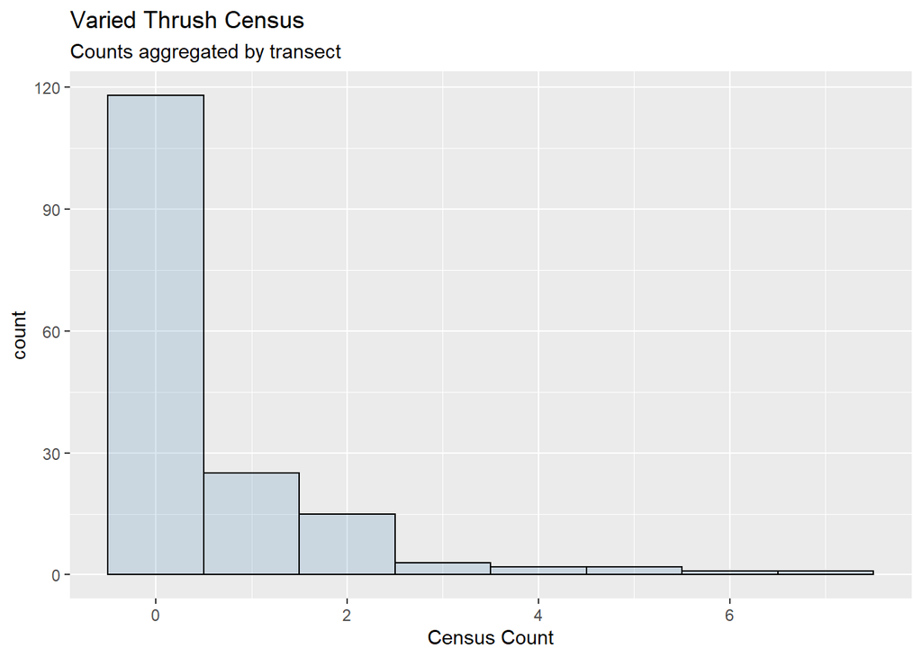

### 5.2.2 Terrain Histograms

How are the terrain covariates distributed among the sample point locations?

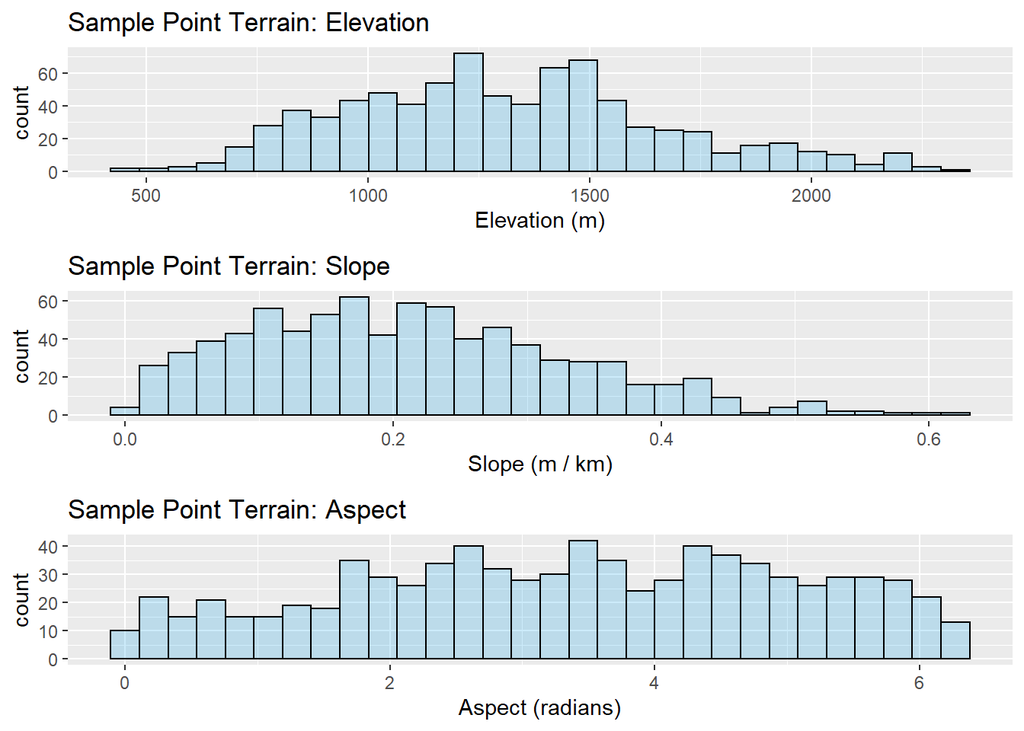

### 5.2.3 Conditional terrain histograms

Are the distributions of the terrain variables similar at sampling points where thrushes were **present** and **absent**?

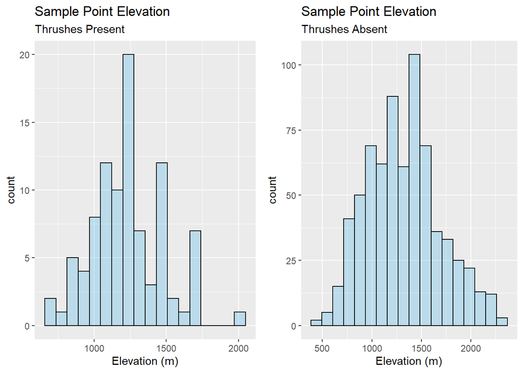

```r
plot_grid(g_hist_elev_present, g_hist_elev_absent, nrow = 1)
```

## 5.3 Pairplots

We can look to see if any of the terrain variables are correlated:

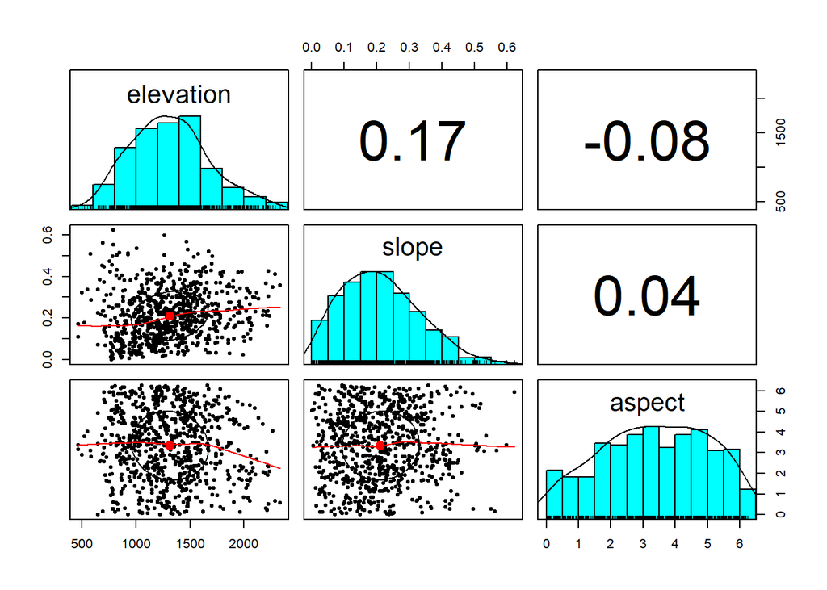

```r
{
  pairs.panels(
    data.frame(thrush_sf)[,
                          c("elevation", "slope", "aspect")])
}
```

# 6 Maps

## 6.1 Study Site

Physical characteristics of the study area:

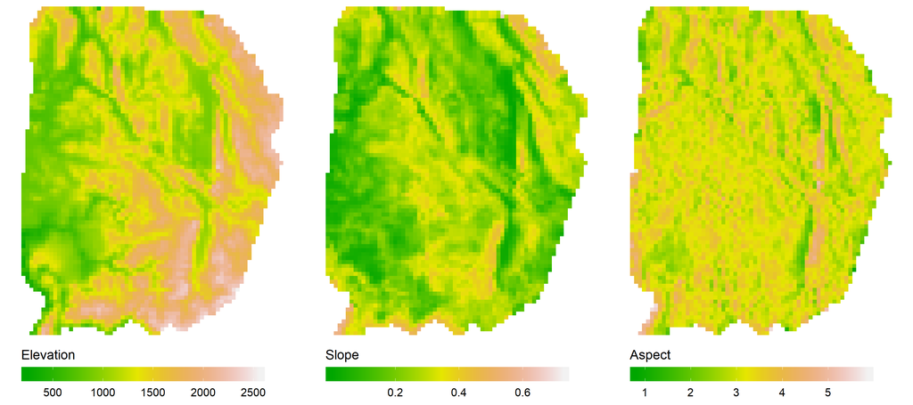

```r
{
  # original raster set for hi-resolution maps
  dat_br = terrain_brick

  # reduced-resolution raster set to speed up plotting
  dat_br = terrain_brick_rs

  # Select which color ramps to use for the maps
  cols = gg_map_grayscale
  cols = gg_map_terr

  map_elev =
    gg_map +
    geom_stars(data = dat_br[, , , 1]) +
    labs(fill = "Elevation") + cols

  map_slope =
    gg_map +
    geom_stars(data = dat_br[, , , 2]) +
    labs(fill = "Slope") + cols

  map_aspect =
    gg_map +
    geom_stars(data = dat_br[, , , 3]) +
    labs(fill = "Aspect") + cols

  map_terrain =
    plot_grid(
      map_elev,
      map_slope,
      map_aspect,
      nrow = 1)
}
```

## 6.2 Sampling Locations

Transects and selected census sites within transects (2nd panel).

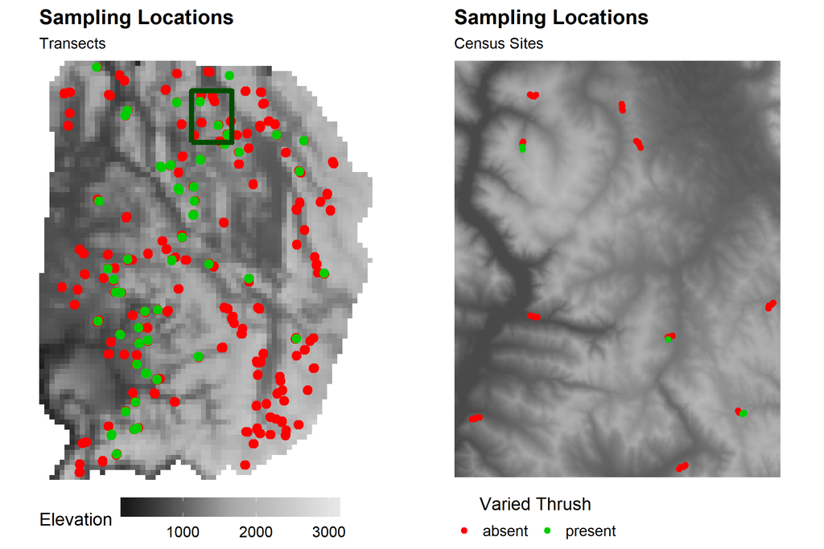

```r
{
  bb_inset = st_bbox(
    c(xmin = 170000,
      xmax = 210000,
      ymin = 500000,
      ymax = 551000),
    crs = crs_dat)

  # full resolution
  dat_br = terrain_brick

  # To speed  up test plots
  dat_br = terrain_brick_rs

  st_crs(terrain_brick_rs) = crs_dat

  thrush_inset = st_crop(thrush_sf, bb_inset)
  elev_inset = st_crop(terrain_brick[, , , 1], bb_inset)

  thrush_inset = st_crop(thrush_sf, bb_inset)
  elev_inset = st_crop(terrain_brick[, , , 1], bb_inset)

  cols = gg_thrush_elevation
  sc_census = scale_color_manual(name = "Varied Thrush", values = c(2, 3))

  thrush_inset_poly =
    geom_sf(data = st_as_sfc(bb_inset),
            fill = "transparent",
            col = rgb(0, 0.3, 0.001), size = 1.9)

  thrush_map =
    gg_map +
    geom_stars(data = dat_br[, , , 1]) +
    geom_sf(
      aes(colour = present),
      data = thrush_sf,
      size = 3, show.legend = FALSE) +
    labs(
      title = "Sampling Locations",
      subtitle = "Transects",
      fill = "Elevation") + cols + sc_census

  thrush_inset_map =
    gg_map +
    geom_stars(data = elev_inset, show.legend = FALSE) +
    geom_sf(
      aes(colour = present),
      data = thrush_inset,
      size = 2,
      show.legend = "point") +
    labs(
      title = "Sampling Locations",
      subtitle = "Census Sites",
      fill = "Elevation") +
    cols + sc_census +
    guides(
      colour = guide_legend(title.position="top", title.hjust = 0.5))
  # theme(legend.title = element_blank())

  thrush_map_full = plot_grid(
    thrush_map + thrush_inset_poly,
    thrush_inset_map, nrow = 1)

}
```

# 7 Aspatial model building

Let’s try three aspatial **logistic regression models**:

We’ll use three different sets of predictors.

## 7.1 Elevation

```r
{
  fit_elev_sc = glm(
    VATH ~ elevation_sc,
    family = "binomial",
    data = thrush_sf)
  summary(fit_elev_sc)
}
```

```
##
## Call:
## glm(formula = VATH ~ elevation_sc, family = "binomial", data = thrush_sf)
##
## Deviance Residuals:
##     Min       1Q   Median       3Q      Max
## -0.6571  -0.5324  -0.4821  -0.4314   2.2940
##
## Coefficients:
##              Estimate Std. Error z value Pr(>|z|)
## (Intercept)   -2.0362     0.1117  -18.22   <2e-16 ***
## elevation_sc  -0.2576     0.1145   -2.25   0.0244 *
## ---
## Signif. codes:  0 '***' 0.001 '**' 0.01 '*' 0.05 '.' 0.1 ' ' 1
##
## (Dispersion parameter for binomial family taken to be 1)
##
##     Null deviance: 584.34  on 804  degrees of freedom
## Residual deviance: 579.10  on 803  degrees of freedom
## AIC: 583.1
##
## Number of Fisher Scoring iterations: 5
```

## 7.2 Elevation, slope, aspect

```r
{
  fit_terrain_sc = glm(
    VATH ~ elevation_sc + slope_sc + aspect_sc,
    family = "binomial",
    data = thrush_sf)
  summary(fit_terrain_sc)
}
```

```
##
## Call:
## glm(formula = VATH ~ elevation_sc + slope_sc + aspect_sc, family = "binomial",
##     data = thrush_sf)
##
## Deviance Residuals:
##     Min       1Q   Median       3Q      Max
## -0.7206  -0.5383  -0.4767  -0.4207   2.3431
##
## Coefficients:
##              Estimate Std. Error z value Pr(>|z|)
## (Intercept)  -2.04547    0.11261 -18.165   <2e-16 ***
## elevation_sc -0.25133    0.11607  -2.165   0.0304 *
## slope_sc     -0.08625    0.11151  -0.773   0.4393
## aspect_sc    -0.12952    0.10963  -1.181   0.2374
## ---
## Signif. codes:  0 '***' 0.001 '**' 0.01 '*' 0.05 '.' 0.1 ' ' 1
##
## (Dispersion parameter for binomial family taken to be 1)
##
##     Null deviance: 584.34  on 804  degrees of freedom
## Residual deviance: 576.99  on 801  degrees of freedom
## AIC: 584.99
##
## Number of Fisher Scoring iterations: 5
```

## 7.3 Quadratic elevation

```r
{
  fit_elev_poly_sc =  glm(
    VATH ~ elevation_sc + I(elevation_sc^2),
    family = "binomial",
    data = thrush_sf)
  summary(fit_elev_poly_sc)
}
```

```
##
## Call:
## glm(formula = VATH ~ elevation_sc + I(elevation_sc^2), family = "binomial",
##     data = thrush_sf)
##
## Deviance Residuals:
##     Min       1Q   Median       3Q      Max
## -0.6088  -0.5787  -0.5032  -0.3231   3.0804
##
## Coefficients:
##                   Estimate Std. Error z value Pr(>|z|)
## (Intercept)        -1.6531     0.1388 -11.909  < 2e-16 ***
## elevation_sc       -0.3743     0.1662  -2.252 0.024329 *
## I(elevation_sc^2)  -0.5699     0.1631  -3.494 0.000475 ***
## ---
## Signif. codes:  0 '***' 0.001 '**' 0.01 '*' 0.05 '.' 0.1 ' ' 1
##
## (Dispersion parameter for binomial family taken to be 1)
##
##     Null deviance: 584.34  on 804  degrees of freedom
## Residual deviance: 560.54  on 802  degrees of freedom
## AIC: 566.54
##
## Number of Fisher Scoring iterations: 6
```

# 8 Aspatial Model Diagnostics

In this example, I’m including only some **very** basice model diagnostics: residual plots. I’m also going to proceed as if the diagnostics were totally fine. In a real analysis, you’d want to perform a more thorough set of model diagnostics.

Here’s a very nice article about plotting residuals with ggplot: [Visualising Residuals by Simon Jackson](https://drsimonj.svbtle.com/visualising-residuals)

The following are simple base R plots:

## 8.1 Elevation Model

Elevation vs residuals and predicted vs. residuals plots for model 1:

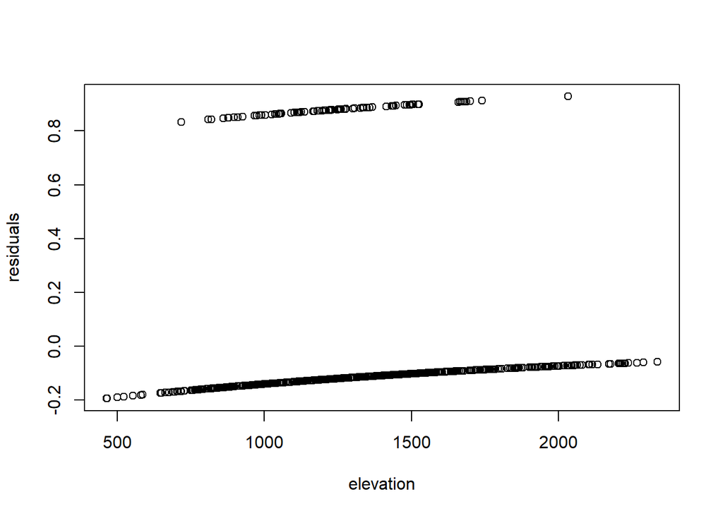

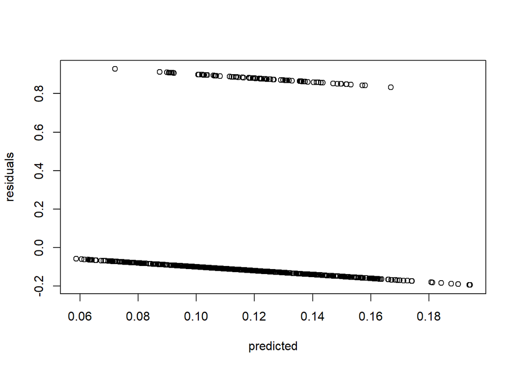

```r
{
  dat_fit_1 = data.frame(thrush_sf)
  dat_fit_1$predicted = predict(fit_elev_sc, type="response")
  dat_fit_1$residuals = residuals(fit_elev_sc, type="response")

  # plot residuals against elevation (the predictor)
  plot(residuals ~ elevation, data = dat_fit_1)

  # Plot residuals against the predicted values
  plot(residuals ~ predicted, data = dat_fit_1)
}
```

## 8.2 Quadratic Elevation Model

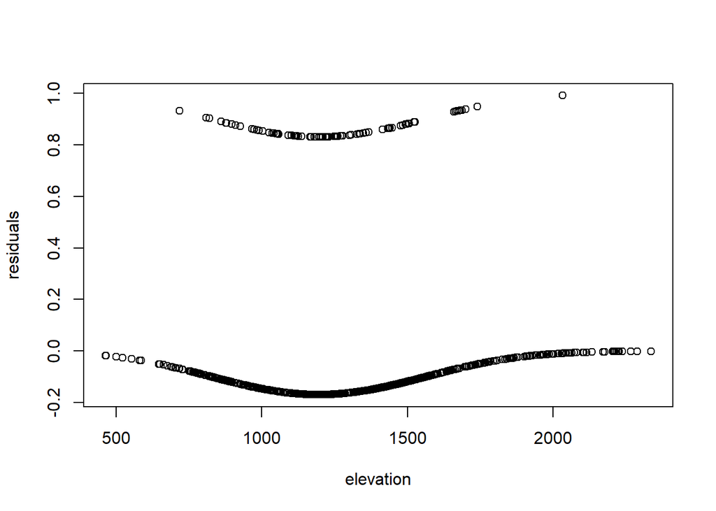

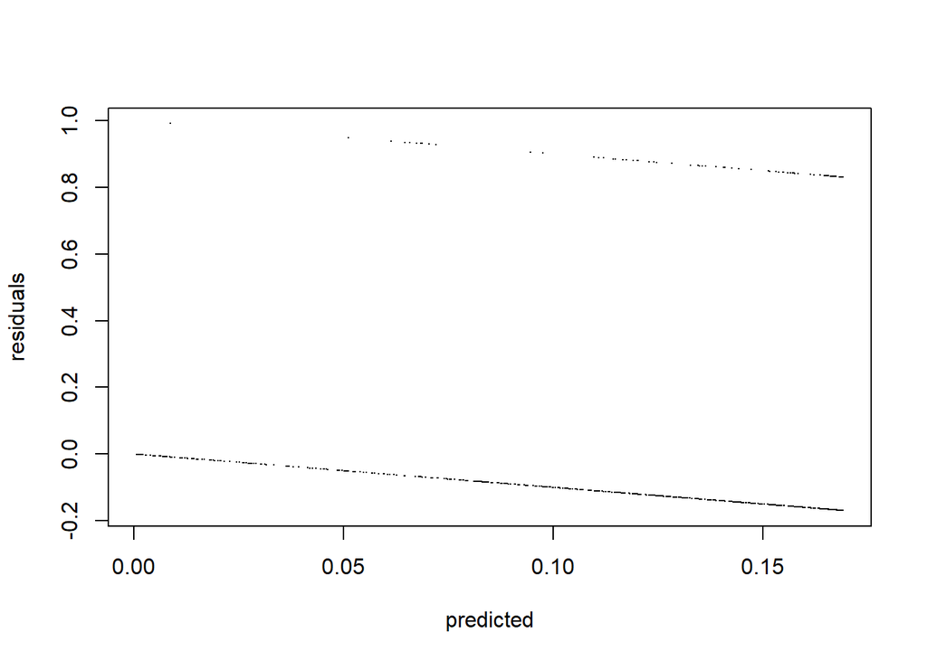

```r
{
  dat_fit_3 = data.frame(thrush_sf)
  dat_fit_3$predicted = predict(fit_elev_poly_sc, type="response")
  dat_fit_3$residuals = residuals(fit_elev_poly_sc, type="response")
  # plot residuals against elevation (the predictor)

  plot(residuals ~ elevation, data = dat_fit_3)

  # Plot residuals against the predicted values
  plot(residuals ~ predicted, data = dat_fit_3, pch = 16, cex = 0.1)
}
```

# 9 Model Selection

We’ll use a very simple model selection process: the Akaike Information Criterion (AIC).

The AIC attempts to balance model complexity with model fit. A low AIC value indicates a ‘better’ model.

```r
{
  AIC(fit_elev_sc, fit_terrain_sc, fit_elev_poly_sc)
}
```

```
##                  df      AIC
## fit_elev_sc       2 583.1021
## fit_terrain_sc    4 584.9933
## fit_elev_poly_sc  3 566.5389
```

The quadratic elevation model seems to be the best because its AIC is the lowest, by around 17.

NOTE: AIC and model selection are complex topics, this is a very simplified selection procedure. In real life you would perform a more thoughtful and thorough model selection procedure.